## **Course Project: M-L based Exercise Manner Prediction**

### **Data Loading & cleaning**

We set the working dicrectory, load essential packages and training and testing data. Note that all predict varibles are set to be numerical type.

```r
library(caret)
```

```r
library(ggplot2)
library(gridExtra)
train_dat <- read.csv("pml-training.csv",header=T)
vali_dat <- read.csv("pml-testing.csv",header=T)
train_dat <- train_dat[,-1] #the 1st colume X is obviously not regarded as predictor.
vali_dat <- vali_dat[,-1]
for (i in 1:(dim(train_dat)[2]-1)) { train_dat[,i] <- as.numeric(train_dat[,i])}
for (i in 1:(dim(vali_dat)[2]-1)) { vali_dat[,i] <- as.numeric(vali_dat[,i])}
```

We further filter out the train_dat varibles containing of NA to obtain more efficient and reasonable models. After that, the number of variables is reduced to 92.

```r
ind <- NULL
for (i in 1:(dim(train_dat)[2])) {
ind[i] <- all(!is.na(train_dat[,i]))
}
train_dat <- train_dat[,ind]
vali_dat <- vali_dat[,ind]
dim(train_dat)[2]
```

```
## [1] 92
```

Then we filter out the varibles nearly without variance which cab barely explain the model. After that, the number of variables is reduced to 58.

```r
ind2 <- nearZeroVar(train_dat[,-dim(train_dat)[2]])
train_dat <- train_dat[,-ind2]
vali_dat <- vali_dat[,-ind2]
dim(train_dat)[2]
```

```
## [1] 58
```

### **Model Construction & Prediction**

#### PCA Preprocessing

The clean dataset has been splitted in a 60% training and 40% testing subset.

```r
inTrain <- createDataPartition(y=train_dat$class,p=0.6,list=F)
training <- train_dat[inTrain,]
testing <- train_dat[-inTrain,]
```

Then the PCA is employed to trainsform the data to another space where the variables are uncorrelated with the others.

```r
preProc <- preProcess(training[,-58],method=c("BoxCox","center","scale","pca"),thresh=0.8)
trainPC <- predict(preProc,training[,-58])
preProc
```

```
##
## Call:
## preProcess.default(x = training[, -58], method = c("BoxCox",
##  "center", "scale", "pca"), thresh = 0.8)
##
## Created from 11776 samples and 57 variables
## Pre-processing: Box-Cox transformation, centered, scaled,
##  principal component signal extraction
##
## Lambda estimates for Box-Cox transformation:
##    Min. 1st Qu.  Median    Mean 3rd Qu.    Max.    NA's
##   0.600   0.700   0.700   1.086   1.450   2.000      50
##
## PCA needed 14 components to capture 80 percent of the variance
```

To find some interesting patterns in classifying outcomes by those PCs. Here we illustrate them by x-y scatterplots with pairs of some PCs.

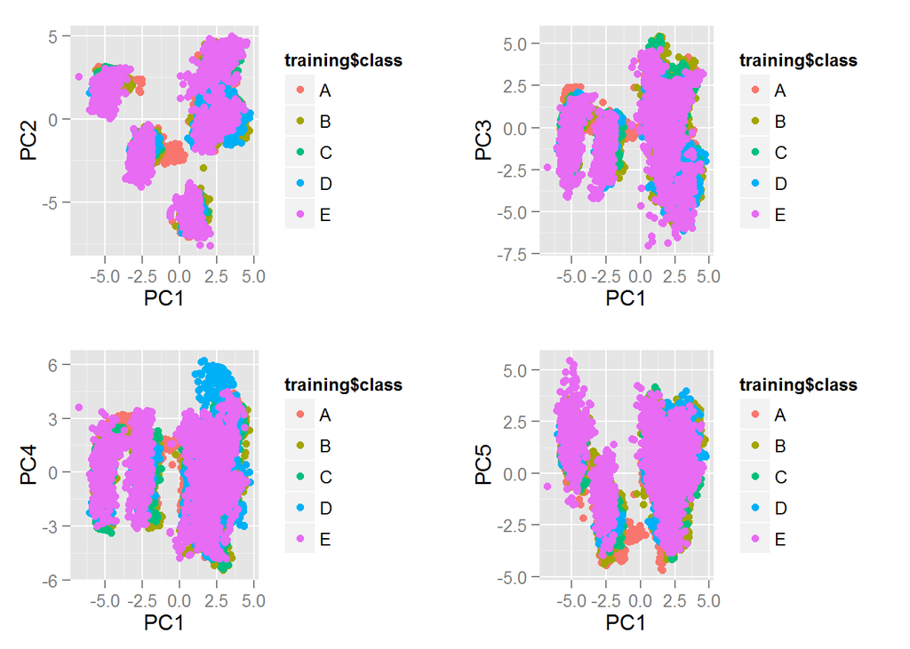

```r
a=ggplot(trainPC,aes(PC1,PC2,color=training$class))+geom_point()
b=ggplot(trainPC,aes(PC1,PC3,color=training$class))+geom_point()
c=ggplot(trainPC,aes(PC1,PC4,color=training$class))+geom_point()
d=ggplot(trainPC,aes(PC1,PC5,color=training$class))+geom_point()
grid.arrange(a,b,c,d,ncol=2)
```

#### RM (Random Forest) Algorithm Training & Testing

In this session, we employ the **Random Forest**, a most commonly used and powerful algorithm. The model has been resampled with **10-fold cross-validation**.

```r
if (file.exists("modelRF.rda")) {
  load(file="modelRF.rda")
} else {
  train_cont <- trainControl(method="cv",number=10)
  modelFit <- train(training$class~.,method="rf",data=trainPC,trControl=train_cont,prox=T)
  save(modelFit,file="modelRF.rda")
}
modelFit
```

[output not shown]

```r
pred <- predict(modelFit,trainPC)
confusionMatrix(pred,training$classe)
```

```
## Confusion Matrix and Statistics
##
##           Reference
## Prediction    A    B    C    D    E
##          A 3348    0    0    0    0
##          B    0 2279    0    0    0
##          C    0    0 2054    0    0
##          D    0    0    0 1930    0
##          E    0    0    0    0 2165
##
## Overall Statistics
##
##                Accuracy : 1
##                  95% CI : (0.9997, 1)
##     No Information Rate : 0.2843
##     P-Value [Acc > NIR] : < 2.2e-16
##
##                   Kappa : 1
##  Mcnemar's Test P-Value : NA
##
## Statistics by Class:
##
##                      Class: A Class: B Class: C Class: D Class: E
## Sensitivity            1.0000   1.0000   1.0000   1.0000   1.0000
## Specificity            1.0000   1.0000   1.0000   1.0000   1.0000
## Pos Pred Value         1.0000   1.0000   1.0000   1.0000   1.0000
## Neg Pred Value         1.0000   1.0000   1.0000   1.0000   1.0000
## Prevalence             0.2843   0.1935   0.1744   0.1639   0.1838
## Detection Rate         0.2843   0.1935   0.1744   0.1639   0.1838
## Detection Prevalence   0.2843   0.1935   0.1744   0.1639   0.1838
## Balanced Accuracy      1.0000   1.0000   1.0000   1.0000   1.0000
```

Then we test the model with the testing subdateset.

```r
testPC <- predict(preProc,testing[,-58])
pred <- predict(modelFit,testPC)
confusionMatrix(testing$classe,pred)
```

```
## Confusion Matrix and Statistics
##
##           Reference
## Prediction    A    B    C    D    E
##          A 2179   19   18   13    3
##          B   27 1462   29    0    0
##          C   14   12 1331   10    1
##          D    6    1   63 1214    2
##          E    1   13   11   14 1403
##
## Overall Statistics
##
##                Accuracy : 0.9672
##                  95% CI : (0.9631, 0.9711)
##     No Information Rate : 0.2838
##     P-Value [Acc > NIR] : < 2.2e-16
##
##                   Kappa : 0.9586
##  Mcnemar's Test P-Value : 1.75e-13
##
## Statistics by Class:
##
##                      Class: A Class: B Class: C Class: D Class: E
## Sensitivity            0.9784   0.9701   0.9167   0.9704   0.9957
## Specificity            0.9906   0.9912   0.9942   0.9891   0.9939
## Pos Pred Value         0.9763   0.9631   0.9730   0.9440   0.9730
## Neg Pred Value         0.9914   0.9929   0.9813   0.9944   0.9991
## Prevalence             0.2838   0.1921   0.1851   0.1594   0.1796
## Detection Rate         0.2777   0.1863   0.1696   0.1547   0.1788
## Detection Prevalence   0.2845   0.1935   0.1744   0.1639   0.1838
## Balanced Accuracy      0.9845   0.9807   0.9554   0.9798   0.9948
```

We can see the **out-of-sample accuracy** is close to 1, indicating a good performance RF model has been constructed.

### **Exercise Manner Prediction by RF**

Finaly, we perform the constructed RF model on the clean vali_dat dataset and obtain the results.

```r
validPC <- predict(preProc,vali_dat[,-58])
res <- predict(modelFit,validPC)
res
```

```
##  [1] B A A A A E D B A A B C B A E E A B B B
## Levels: A B C D E
```